# Project4

Ciaran Lowell

Advanced Applied Machine Learning

Project 4

4/7/2021

# Physicochemical Properties of Protein Tertiary Structure

For this project, we will be using a Linear Generalized Additive Model and the Nadaraya-Watson kernel density estimator to analyze Protein Structure data. To calculate the quality of our predictions, we'll look at the R^2 coefficient as well as RSME with 10 cross-fold validations.

Using the Yellowbrick library, we'll show a residual scatterplot and histogram for one of our K-Folds. This graph will help show any patterns of error in our models.

```python
from google.colab import drive
drive.mount('/content/drive')
```

```python
cd /content/drive/MyDrive/Colab Notebooks
```

```
/content/drive/MyDrive/Colab Notebooks
```

```python
from nadaraya_watson import NadarayaWatson, NadarayaWatsonCV
```

```python
pip install pygam
```

```python
import pandas as pd
import yellowbrick
import numpy as np
from pygam import LinearGAM
from sklearn.model_selection import KFold
from sklearn.preprocessing import StandardScaler
import matplotlib.pyplot as plt
from sklearn.metrics import mean_squared_error as mse
from sklearn.model_selection import train_test_split as tts
from sklearn.model_selection import GridSearchCV
from sklearn.model_selection import cross_val_predict
import matplotlib as mpl
import matplotlib.pyplot as plt
from yellowbrick.regressor import ResidualsPlot
from yellowbrick.regressor import residuals_plot
from sklearn.base import BaseEstimator, RegressorMixin
from sklearn.model_selection import GridSearchCV
from scipy.optimize import minimize
from sklearn.utils.validation import check_X_y, check_array, check_is_fitted
```

# Definitions

Class GAMsk is created for later use of Yellowbrick to analyze and graph residuals.

Function run_Kfold is created to run a K-Fold cross validation loop for later use. This function uses Yellowbrick to print a residual scatterplot and histogram of a k-fold.

This function also calculates the Root Mean Square Error of the model on each Train/Test set. The function returns the average Train and Test error of the model across all k-folds.

```python
class GAMsk(BaseEstimator, RegressorMixin):
    def __init__(self, ns= None):
        self.ns = ns

    def fit(self, X, y,):
        X, y = check_X_y(X, y)

        if self.ns is None:
            gam = LinearGAM(n_splines= 12).gridsearch(X, y, keep_best = True,objective='GCV')
            self.pred_ = gam
        else:
            gam = LinearGAM(n_splines=self.ns).gridsearch(X, y, keep_best = True, objective='GCV')
            self.pred_ = gam
        return self

    def predict(self, X):
        check_is_fitted(self)
        X = check_array(X)
        return self.pred_.predict(X).reshape(-1,1)
```

```python
def run_Kfold(X, y, k, random, modelTest):
  count = 0
  PredErrorInternal = []
  PredErrorExternal = []
  kf = KFold(n_splits = k, shuffle = True, random_state = random)
  for idxtrain, idxtest in kf.split(X):
    X_train = X[idxtrain,:]
    y_train = y[idxtrain]
    X_test = X[idxtest,:]
    y_test = y[idxtest]
    model = modelTest
    model = model.fit(X_train, y_train.ravel())
    yhat_test = model.predict(X_test)
    yhat_train = model.predict(X_train)
    PredErrorExternal.append(mse(y_test, yhat_test, squared = False))
    PredErrorInternal.append(mse(y_train, yhat_train, squared = False))
    ##For our final K-fold, we'll create a scatter plot and histogram of our residuals
    if count == (k):
      visualizer = ResidualsPlot(model)
      visualizer.fit(X_train, y_train)
      visualizer.score(X_test, y_test)
      visualizer.poof()

    count = count + 1

  return np.mean(PredErrorExternal), np.mean(PredErrorInternal)
```

# Data

The data contains information about protein folding structures.

More information about this data (and a prior analysis) can be found [at this link](https://www.researchgate.net/publication/329801503_Modelling_Physicochemical_Properties_for_Protein_Tertiary_Structure_Prediction_Performance_Analysis_of_Regression_Models).

```python
data = pd.read_csv("CASP(1).csv")
data
```

|  | RMSD | F1 | F2 | F3 | F4 | F5 | F6 | F7 | F8 | F9 |
| --- | --- | --- | --- | --- | --- | --- | --- | --- | --- | --- |
| 0 | 17.284 | 13558.30 | 4305.35 | 0.31754 | 162.1730 | 1.872791e+06 | 215.3590 | 4287.87 | 102 | 27.0302 |
| 1 | 6.021 | 6191.96 | 1623.16 | 0.26213 | 53.3894 | 8.034467e+05 | 87.2024 | 3328.91 | 39 | 38.5468 |
| 2 | 9.275 | 7725.98 | 1726.28 | 0.22343 | 67.2887 | 1.075648e+06 | 81.7913 | 2981.04 | 29 | 38.8119 |
| 3 | 15.851 | 8424.58 | 2368.25 | 0.28111 | 67.8325 | 1.210472e+06 | 109.4390 | 3248.22 | 70 | 39.0651 |
| 4 | 7.962 | 7460.84 | 1736.94 | 0.23280 | 52.4123 | 1.021020e+06 | 94.5234 | 2814.42 | 41 | 39.9147 |
| ... | ... | ... | ... | ... | ... | ... | ... | ... | ... | ... |
| 45725 | 3.762 | 8037.12 | 2777.68 | 0.34560 | 64.3390 | 1.105797e+06 | 112.7460 | 3384.21 | 84 | 36.8036 |
| 45726 | 6.521 | 7978.76 | 2508.57 | 0.31440 | 75.8654 | 1.116725e+06 | 102.2770 | 3974.52 | 54 | 36.0470 |
| 45727 | 10.356 | 7726.65 | 2489.58 | 0.32220 | 70.9903 | 1.076560e+06 | 103.6780 | 3290.46 | 46 | 37.4718 |
| 45728 | 9.791 | 8878.93 | 3055.78 | 0.34416 | 94.0314 | 1.242266e+06 | 115.1950 | 3421.79 | 41 | 35.6045 |
| 45729 | 18.827 | 12732.40 | 4444.36 | 0.34905 | 157.6300 | 1.788897e+06 | 229.4590 | 4626.85 | 141 | 29.8118 |

45730 rows × 10 columns

```python
data.shape
```

```
(45730, 10)
```

Our data is around 46000 data points. The RMSD column represents the dependent Y variable, while columns F1 through F9 are the independent X variables. Accordingly, the RMSD column is loaded into an array Y, while the other columns are loaded into an array X.

```python
features = ['F1', 'F2', 'F3', 'F4', 'F5', 'F6', 'F7', 'F8', 'F9']
X = np.array(data[features])
y = np.array(data['RMSD']).reshape(-1,1)
```

Because the Narayada/Watson model depends on the data being standardized around Z-scores, X is transformed using the StandardScaler. This process aids the Narayada/Watson model and does not affect the Linear GAM model.

```python
scaler = StandardScaler()
scaler.fit(X)
X = scaler.transform(X)
X
```

```
array([[ 0.9084815 ,  0.87958425,  0.24088548, ...,  0.14953906,
         0.56688489, -1.25315251],
       [-0.90674028, -0.95212657, -0.64024469, ..., -0.33149159,
        -0.54830097,  0.67280014],
       [-0.52872535, -0.88170426, -1.25565233, ..., -0.50598911,
        -0.7253146 ,  0.71713354],
       ...,
       [-0.52856025, -0.36043438,  0.31498883, ..., -0.35077877,
        -0.42439143,  0.49302494],
       [-0.24461412,  0.02623274,  0.66419689, ..., -0.28490141,
        -0.51289825,  0.18075123],
       [ 0.70496229,  0.97451642,  0.7419577 , ...,  0.3195772 ,
         1.25723804, -0.7879779 ]])
```

# Linear GAM

The linear GAM model is created with 12 splines, which showed best results in early testing stages of this project.

```python
model = GAMsk(ns= 12)
```

### Graphing our Linear GAM Residuals

After performing a Linear GAM analysis using 10-fold cross validation, the Linear GAM model had a RMSE external error **4.976465884428406** of and a RMSE internal error of **4.961546125536189**.

The R^2 of the model was .339 on the Train data and .371 on the Test data. This low R^2 suggests that either Linear GAM is poorly suited to this dataset, or that the model was poorly optimized.

The residual scatterplot exhibits characteristics of a bad model. The residuals are not evenly distributed and appear to have clear trends in both the Training and Test sets.

The residual Histogram shows that the residuals are not entirely normally distributed, and are not symettrical at 0.

The residuals appear heteroscedastic and indicate that the LinearGAM model has consistent error and is not working well for this data set.

[output not shown]

[figure not shown]

```
100% (11 of 11) |########################| Elapsed Time: 0:00:17 Time:  0:00:17
```

```
(4.976465884428406, 4.961546125536189)
```

```python
run_Kfold(X, y, 10, 1693, model)
```

# Nadaraya-Watson Kernel Density Estimator

Because the Nadaraya-Watson implementation automatically uses k-fold validation, I didn't create a k-fold loop like I used for the LinearGAM implmentation. Instead, just uses a simple Train/Test split to show a train/test residual histogram. The model's R^2 and RMSE were still calculated using 10-fold cross validation that is encapsulated within the model.

The Nadaraya-Watson Kernel Density Estimator had an overall Test RMSE of 4.037633142782846 and a mean R^2 = .5510379747700558 over the test datasets. These results are fairly poor, but still indicate better performance than the LinearGAM model.

The residual plots shows some of the same trends present in the LinearGAM model, but with a more normalized residual histogram that is more symmetrical across 0.

```python
param_grid=dict(kernel=["rbf"],gamma=np.linspace(0, 100, 10))

modelNW= GridSearchCV(NadarayaWatson(), cv=10, param_grid=param_grid, scoring = ['r2', 'neg_root_mean_squared_error'], refit = 'r2' , verbose = 0)
```

```python
modelNW.fit(X, y)
```

```
GridSearchCV(cv=10, error_score=nan,
             estimator=NadarayaWatson(coef0=1, degree=3, gamma=None,
                                      kernel='linear', kernel_params=None),
             iid='deprecated', n_jobs=None,
             param_grid={'gamma': array([  0.        ,  11.11111111,  22.22222222,  33.33333333,
        44.44444444,  55.55555556,  66.66666667,  77.77777778,
        88.88888889, 100.        ]),
                         'kernel': ['rbf']},
             pre_dispatch='2*n_jobs', refit='r2', return_train_score=False,
             scoring=['r2', 'neg_root_mean_squared_error'], verbose=0)
```

```python
NWTestRMSE = np.mean(np.abs(modelNW.cv_results_['mean_test_neg_root_mean_squared_error']))
NWTestR2 = np.mean(modelNW.cv_results_['mean_test_r2'])
```

```python
print("NW Test RMSE = " + str(NWTestRMSE) + ", NW Test R2 = " + str(NWTestR2))
```

```
NW Test RMSE = 4.037633142782846, NW Test R2 = 0.5510379747700558
```

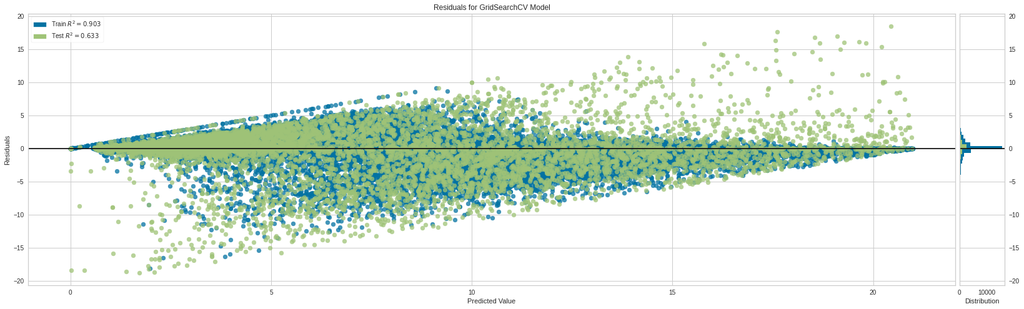

```python
X_train, X_test, y_train, y_test = tts(X, y, test_size=0.2, shuffle=True)
visualizer = ResidualsPlot(modelNW)
visualizer.fit(X_train, y_train)
visualizer.score(X_test, y_test)
visualizer.poof()
```

# Summary

Linear GAM did a poor job of predicting Protein Folding based on the input data. The residuals showed heteroscedasticity that indicates the Linear GAM model was not suitable for the dataset.

The Nadaraya-Watson model had improved prediction accuracy but still had some worrying trends in the residual plot.

Both models had similarly shaped irregular residual plots, which could indicate that there is a variable we are not accounting for, or that the models were poorly fit to the data. Both models have similar "bounded" looking distributions.